# Turn up the Heat! A Tutorial for the MAGMA R-package.

### Balance Estimation and Visualization

We only need to change the specific object names, covariates, grouping variable, and the filename for the table. Otherwise, the process of balance estimation and visualization remains the same.

```r
Balance_tar <- Balance_MAGMA(Data = MAGMA_sim_data_tar,
                             group = "teacher_ability_rating",
                             covariates = covariates_tar,
                             step = "step")
```

```
#>
#>  Start estimating Pillai's Trace.
#>  Pillai's Trace finished. Starting to compute d-ratio.
#>  d-ratio finished. Starting to compute mean-g.
#>
#>  Mean g was computed using robust variance meta-analysis with robumeta.
#>  Mean g finished. Starting to compute adjusted d-ratio.
#>  Adjusted d-ratio finished. balance estimation
```

```r
# Balance criteria for 100 cases per group
Balance_100_tar_criteria <- Balance_extract(Balance = Balance_tar,
                                            samplesize = 100,
                                            effects = FALSE)
Balance_100_tar_criteria
```

```
#> Pillai's Trace        d-ratio         mean g   adj. d-ratio
#>           0.03           0.67           0.14           0.64
```

```r
# Extracting pairwise effects for 100 cases per group
Balance_100_tar_effects <- Balance_extract(Balance = Balance_tar,
                                           samplesize = 100,
                                           effects = TRUE)
Balance_100_tar_effects
```

```
#>       GPA_school_1_2         IQ_score_1_2       Motivation_1_2
#>                 0.32                 0.22                 0.20
#> parents_academic_1_2   gifted_support_1_2       GPA_school_1_3
#>                 0.04                 0.00                 0.37
#>         IQ_score_1_3       Motivation_1_3 parents_academic_1_3
#>                 0.23                 0.07                 0.14
#>   gifted_support_1_3       GPA_school_2_3         IQ_score_2_3
#>                 0.04                 0.03                 0.05
#>       Motivation_2_3 parents_academic_2_3   gifted_support_2_3
#>                 0.26                 0.10                 0.04
```

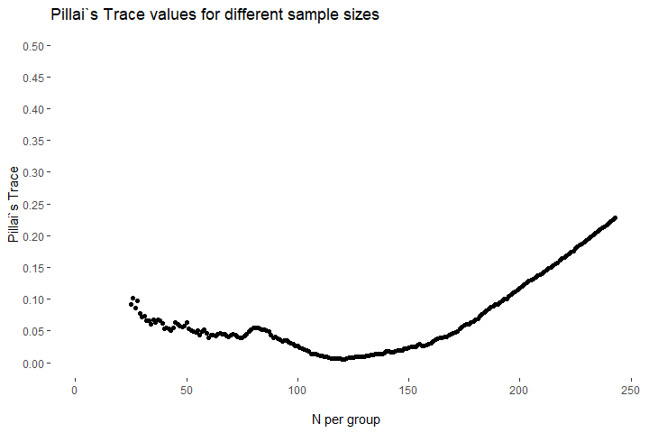

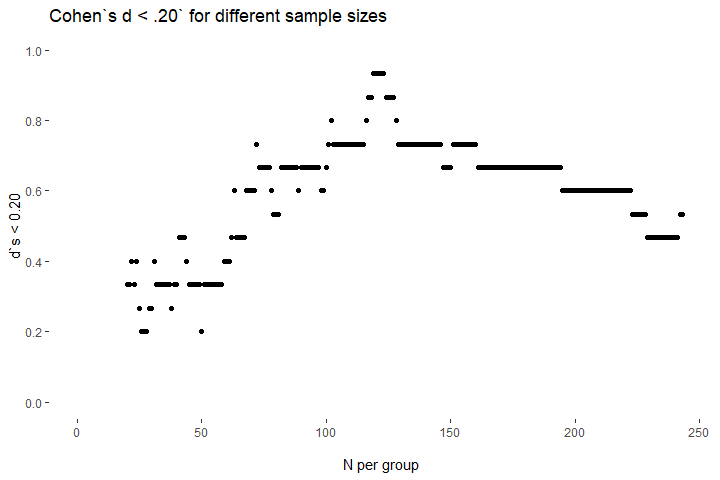

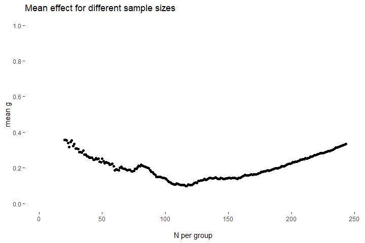

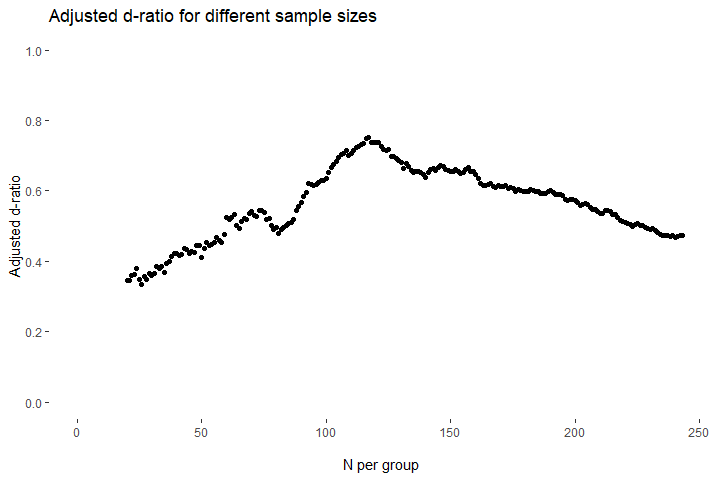

```r
# Plotting trend over increasing sample size
Plot_MAGMA(Balance = Balance_tar,
           criterion = c("Pillai", "d_ratio", "mean_g", "Adj_d_ratio"))
```

```r
# Creating table
Table_MAGMA(Balance = Balance_tar,
            filename = "Balance_tar.docx")
```

```
#> Balance table successfully created!
#> # A tibble: 4 × 6
#>   Criterion_optimized Pillai_Trace d_ratio mean_g adjusted_d_ratio n_per_group
#>   <chr>                      <dbl>   <dbl>  <dbl>            <dbl>       <int>
#> 1 Best mean g                 0.01    0.8    0.1              0.75         116
#> 2 Best adj. d-ratio           0.01    0.87   0.1              0.75         117
#> 3 Best Pillai                 0.01    0.93   0.11             0.74         121
#> 4 Best d-ratio                0.01    0.93   0.12             0.72         123
```

```r
Balance_tar <- Balance_MAGMA(Data = MAGMA_sim_data_tar,
                             group = "teacher_ability_rating",
                             covariates = covariates_tar,
                             step = "step")
```

```r
# Balance criteria for 100 cases per group
Balance_100_tar_criteria <- Balance_extract(Balance = Balance_tar,
                                            samplesize = 100,
                                            effects = FALSE)
Balance_100_tar_criteria
```

```
#> Pillai's Trace        d-ratio         mean g   adj. d-ratio
#>           0.03           0.67           0.14           0.64
```

```r
# Extracting pairwise effects for 100 cases per group
Balance_100_tar_effects <- Balance_extract(Balance = Balance_tar,
                                           samplesize = 100,
                                           effects = TRUE)
Balance_100_tar_effects
```

```
#>       GPA_school_1_2         IQ_score_1_2       Motivation_1_2
#>                 0.32                 0.22                 0.20
#> parents_academic_1_2   gifted_support_1_2       GPA_school_1_3
#>                 0.04                 0.00                 0.37
#>         IQ_score_1_3       Motivation_1_3 parents_academic_1_3
#>                 0.23                 0.07                 0.14
#>   gifted_support_1_3       GPA_school_2_3         IQ_score_2_3
#>                 0.04                 0.03                 0.05
#>       Motivation_2_3 parents_academic_2_3   gifted_support_2_3
#>                 0.26                 0.10                 0.04
```

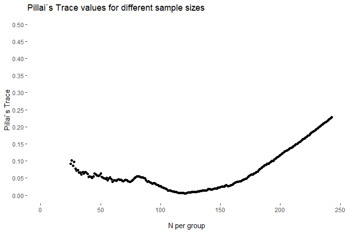

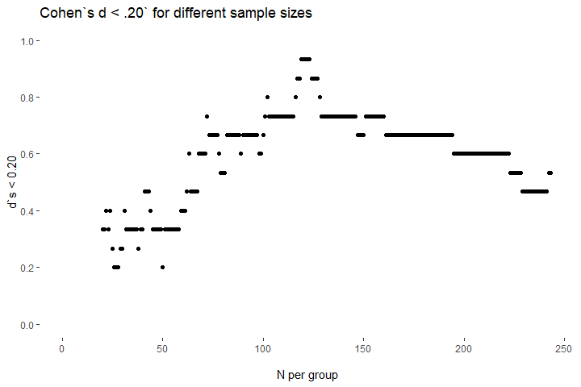

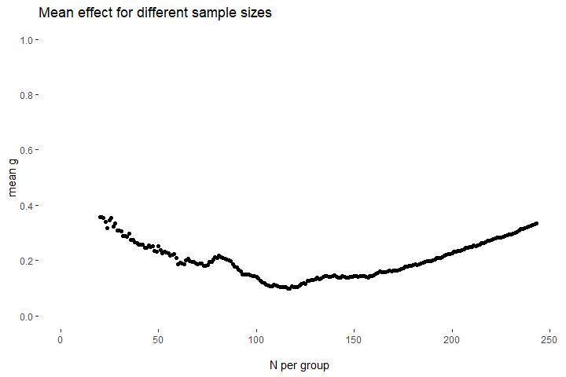

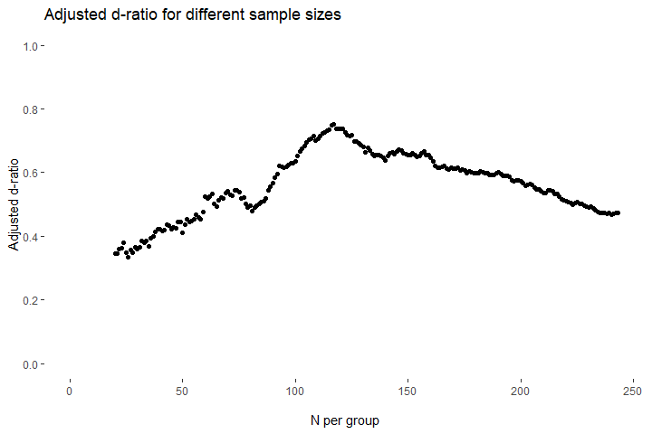

```r
# Plotting trend over increasing sample size
Plot_MAGMA(Balance = Balance_tar,
           criterion = c("Pillai", "d_ratio", "mean_g", "Adj_d_ratio"))
```

```r
# Creating table
Table_MAGMA(Balance = Balance_tar,
            filename = "Balance_tar.docx")
```

```
#> Balance table successfully created!
#> # A tibble: 4 × 6
#>   Criterion_optimized Pillai_Trace d_ratio mean_g adjusted_d_ratio n_per_group
#>   <chr>                      <dbl>   <dbl>  <dbl>            <dbl>       <int>
#> 1 Best mean g                 0.01    0.8    0.1              0.75         116
#> 2 Best adj. d-ratio           0.01    0.87   0.1              0.75         117
#> 3 Best Pillai                 0.01    0.93   0.11             0.74         121
#> 4 Best d-ratio                0.01    0.93   0.12             0.72         123
```

### Post-matching statistics

After selecting a final solution we can report the post-matching descriptive statistics. To this end, we need to adapt our arguments to this three-group example.

```r
# Computing descriptive statistics and pairwise effects for 100 cases per group
descs_tar_post <- MAGMA_desc(Data = MAGMA_sim_data_tar,
                            group = "teacher_ability_rating",
                            covariates = covariates_tar,
                            step_num = 100,
                            step_var = "step",
                            filename = "stats_tar_post.docx")

# Displaying the table with defined colum names
descs_tar_post %>%
    purrr::set_names(c("Overall N", "Overall Mean", "Overall SD",
                       "BA N", "BA Support Mean", "BA Support SD",
                       "A N", "A Mean", "A SD",
                       "AA N", "AA Mean", "AA SD",
                       "d BA-A", "d BA-AA", "d A-AA"))
```

```
#>                        Overall N Overall Mean Overall SD BA N BA Support Mean
#> teacher_ability_rating       300         2.00       0.82  100            1.00
#> GPA_school                   300         3.21       0.66  100            3.36
#> IQ_score                     300        99.29      12.99  100          101.19
#> Motivation                   300         3.86       0.87  100            3.89
#> parents_academic             300         0.39       0.49  100            0.42
#> gifted_support               300         0.41       0.49  100            0.42
#>                        BA Support SD A N A Mean  A SD AA N AA Mean AA SD d BA-A
#> teacher_ability_rating          0.00 100   2.00  0.00  100    3.00  0.00   -Inf
#> GPA_school                      0.68 100   3.14  0.70  100    3.12  0.59   0.32
#> IQ_score                       11.71 100  98.67 11.74  100   98.02 15.13   0.22
#> Motivation                      0.86 100   3.73  0.82  100    3.96  0.93   0.19
#> parents_academic                0.50 100   0.40  0.49  100    0.35  0.48   0.04
#> gifted_support                  0.50 100   0.42  0.50  100    0.40  0.49   0.00
#>                        d BA-AA d A-AA
#> teacher_ability_rating    -Inf   -Inf
#> GPA_school                0.38   0.03
#> IQ_score                  0.24   0.05
#> Motivation               -0.08  -0.26
#> parents_academic          0.14   0.10
#> gifted_support            0.04   0.04
```

```r
# Computing descriptive statistics and pairwise effects for 100 cases per group
descs_tar_post <- MAGMA_desc(Data = MAGMA_sim_data_tar,
                            group = "teacher_ability_rating",
                            covariates = covariates_tar,
                            step_num = 100,
                            step_var = "step",
                            filename = "stats_tar_post.docx")

# Displaying the table with defined colum names
descs_tar_post %>%
    purrr::set_names(c("Overall N", "Overall Mean", "Overall SD",
                       "BA N", "BA Support Mean", "BA Support SD",
                       "A N", "A Mean", "A SD",
                       "AA N", "AA Mean", "AA SD",
                       "d BA-A", "d BA-AA", "d A-AA"))
```

```
#>                        Overall N Overall Mean Overall SD BA N BA Support Mean
#> teacher_ability_rating       300         2.00       0.82  100            1.00
#> GPA_school                   300         3.21       0.66  100            3.36
#> IQ_score                     300        99.29      12.99  100          101.19
#> Motivation                   300         3.86       0.87  100            3.89
#> parents_academic             300         0.39       0.49  100            0.42
#> gifted_support               300         0.41       0.49  100            0.42
#>                        BA Support SD A N A Mean  A SD AA N AA Mean AA SD d BA-A
#> teacher_ability_rating          0.00 100   2.00  0.00  100    3.00  0.00   -Inf
#> GPA_school                      0.68 100   3.14  0.70  100    3.12  0.59   0.32
#> IQ_score                       11.71 100  98.67 11.74  100   98.02 15.13   0.22
#> Motivation                      0.86 100   3.73  0.82  100    3.96  0.93   0.19
#> parents_academic                0.50 100   0.40  0.49  100    0.35  0.48   0.04
#> gifted_support                  0.50 100   0.42  0.50  100    0.40  0.49   0.00
#>                        d BA-AA d A-AA
#> teacher_ability_rating    -Inf   -Inf
#> GPA_school                0.38   0.03
#> IQ_score                  0.24   0.05
#> Motivation               -0.08  -0.26
#> parents_academic          0.14   0.10
#> gifted_support            0.04   0.04
```

## Exact Matching

We use the same covariates as we used for the standard three-group matching. The only change is the use of `gender` as exact variable. Thus, girls will only be matched to girls, and boys will only be matched to other boys across the three groups. Initial unbalance, descriptive statistics, and common support are the same as for standard matching. Below you find the entire matching, balance estimation, and visualization process.

```r
MAGMA_sim_data_tar_exact <- MAGMA_exact(Data = MAGMA_sim_data,
                                        group = "teacher_ability_rating",
                                        dist = "ps_tar",
                                        exact = "gender",
                                        cores = 2)
```

```
#>
#>  Input correctly identified!
#>  Distance computation finished. Starting matching
#>  Matching complete!
```

```r
str(MAGMA_sim_data_tar_exact)
```

```
#> 'data.frame':    800 obs. of  17 variables:
#>  $ ID                    : int  1 2 3 4 5 6 7 8 9 10 ...
#>  $ gender                : int  1 0 1 1 1 0 0 0 1 0 ...
#>  $ gifted_support        : int  1 1 1 1 1 1 0 1 0 1 ...
#>  $ teacher_ability_rating: int  3 2 2 1 3 3 2 2 1 1 ...
#>  $ enrichment            : int  0 1 0 1 0 0 0 0 0 1 ...
#>  $ parents_academic      : int  1 1 1 0 1 0 0 1 0 0 ...
#>  $ GPA_school            : num  4.73 4.41 3.23 2.88 2.98 ...
#>  $ IQ_score              : num  111.6 97.8 120.1 97.9 74.4 ...
#>  $ Motivation            : num  5.36 4.41 3.57 4.34 3.54 ...
#>  $ college_GPA           : num  4.01 3.41 2.73 4.02 4.09 ...
#>  $ support_enrichment    : int  3 4 3 4 3 3 1 3 1 4 ...
#>  $ ps_tar                : num  0.0657 0.1085 0.1899 0.4261 0.4782 ...
#>  $ ps_2x2                : num  0.3 0.32 0.21 0.237 0.571 ...
#>  $ ps_gifted             : num  0.431 0.364 0.626 0.353 0.187 ...
#>  $ step                  : num  226 NA 165 108 71 43 188 NA 241 54 ...
#>  $ weight                : num  1 NA 1 1 1 1 1 NA 1 1 ...
#>  $ distance              : num  2.787944 NA 1.040494 0.231533 0.000273 ...
```

```r
Balance_tar_exact <- Balance_MAGMA(Data = MAGMA_sim_data_tar_exact,
                                   group = "teacher_ability_rating",
                                   covariates = covariates_tar,
                                   step = "step")
```

```
#>
#>  Start estimating Pillai's Trace.
#>  Pillai's Trace finished. Starting to compute d-ratio.
#>  d-ratio finished. Starting to compute mean-g.
#>
#>  Mean g was computed using robust variance meta-analysis with robumeta.
#>  Mean g finished. Starting to compute adjusted d-ratio.
#>  Adjusted d-ratio finished. balance estimation
```

```r
# Balance criteria for 100 cases per group
Balance_100_tar_criteria_exact <- Balance_extract(Balance = Balance_tar_exact,
                                                  samplesize = 100,
                                                  effects = FALSE)
Balance_100_tar_criteria_exact
```

```
#> Pillai's Trace        d-ratio         mean g   adj. d-ratio
#>           0.03           0.67           0.16           0.61
```

```r
# Extracting pairwise effects for 100 cases per group
Balance_100_tar_effects_exact <- Balance_extract(Balance = Balance_tar_exact,
                                                 samplesize = 100,
                                                 effects = TRUE)
Balance_100_tar_effects_exact
```

```
#>       GPA_school_1_2         IQ_score_1_2       Motivation_1_2
#>                 0.36                 0.34                 0.10
#> parents_academic_1_2   gifted_support_1_2       GPA_school_1_3
#>                 0.12                 0.12                 0.37
#>         IQ_score_1_3       Motivation_1_3 parents_academic_1_3
#>                 0.24                 0.14                 0.12
#>   gifted_support_1_3       GPA_school_2_3         IQ_score_2_3
#>                 0.04                 0.00                 0.05
#>       Motivation_2_3 parents_academic_2_3   gifted_support_2_3
#>                 0.24                 0.00                 0.08
```

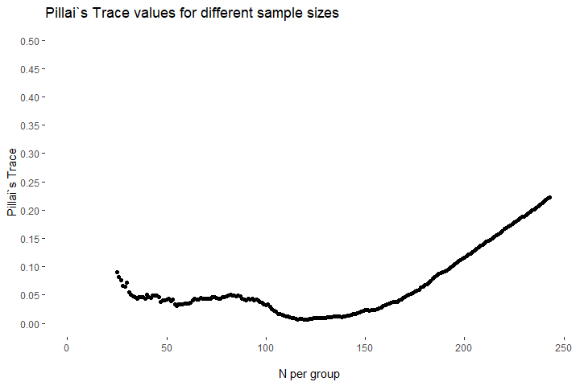

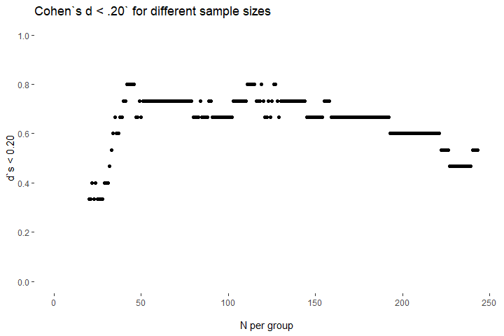

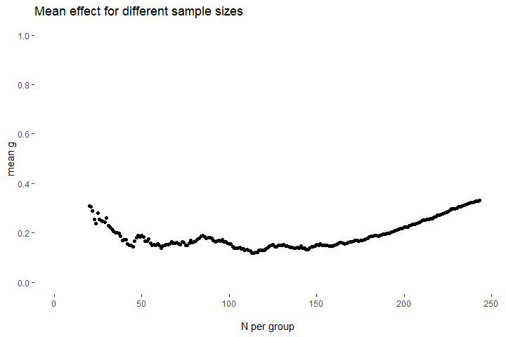

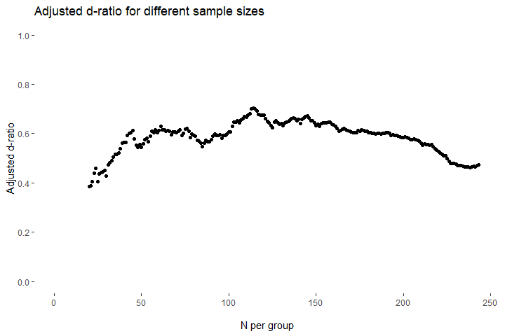

```r
# Plotting trend over increasing sample size
Plot_MAGMA(Balance = Balance_tar_exact,
           criterion = c("Pillai", "d_ratio", "mean_g", "Adj_d_ratio")) #Could be omitted
```

```r
# Creating table
Table_MAGMA(Balance = Balance_tar_exact,
            filename = "Balance_tar_exact.docx")
```

```
#> Balance table successfully created!
#> # A tibble: 4 × 6
#>   Criterion_optimized Pillai_Trace d_ratio mean_g adjusted_d_ratio n_per_group
#>   <chr>                      <dbl>   <dbl>  <dbl>            <dbl>       <int>
#> 1 Best mean g                 0.01    0.8    0.12             0.7          113
#> 2 Best adj. d-ratio           0.01    0.8    0.12             0.7          114
#> 3 Best Pillai                 0.01    0.73   0.12             0.69         116
#> 4 Best d-ratio                0.01    0.8    0.14             0.65         127
```

```r
# Computing descriptive statistics and pairwise effects for 100 cases per group
descs_tar_post_exact <- MAGMA_desc(Data = MAGMA_sim_data_tar_exact,
                                   group = "teacher_ability_rating",
                                   covariates = covariates_tar,
                                   step_num = 100,
                                   step_var = "step",
                                   filename = "stats_tar_post_exact.docx")

# Displaying the table with defined column names
descs_tar_post_exact %>%
    purrr::set_names(c("Overall N", "Overall Mean", "Overall SD",
                       "BA N", "BA Support Mean", "BA Support SD",
                       "A N", "A Mean", "A SD",
                       "AA N", "AA Mean", "AA SD",
                       "d BA-A", "d BA-AA", "d A-AA"))
```

```
#>                        Overall N Overall Mean Overall SD BA N BA Support Mean
#> teacher_ability_rating       300         2.00       0.82  100            1.00
#> GPA_school                   300         3.21       0.65  100            3.37
#> IQ_score                     300        98.95      13.11  100          101.40
#> Motivation                   300         3.83       0.91  100            3.82
#> parents_academic             300         0.38       0.49  100            0.42
#> gifted_support               300         0.39       0.49  100            0.42
#>                        BA Support SD A N A Mean  A SD AA N AA Mean AA SD d BA-A
#> teacher_ability_rating          0.00 100   2.00  0.00  100    3.00  0.00   -Inf
#> GPA_school                      0.68 100   3.13  0.64  100    3.13  0.60   0.37
#> IQ_score                       11.93 100  97.36 11.53  100   98.07 15.30   0.35
#> Motivation                      0.91 100   3.73  0.91  100    3.95  0.90   0.10
#> parents_academic                0.50 100   0.36  0.48  100    0.36  0.48   0.12
#> gifted_support                  0.50 100   0.36  0.48  100    0.40  0.49   0.12
#>                        d BA-AA d A-AA
#> teacher_ability_rating    -Inf   -Inf
#> GPA_school                0.38   0.00
#> IQ_score                  0.24  -0.05
#> Motivation               -0.14  -0.24
#> parents_academic          0.12   0.00
#> gifted_support            0.04  -0.08
```

```r
MAGMA_sim_data_tar_exact <- MAGMA_exact(Data = MAGMA_sim_data,
                                        group = "teacher_ability_rating",
                                        dist = "ps_tar",
                                        exact = "gender",
                                        cores = 2)
```

```r
str(MAGMA_sim_data_tar_exact)
```

```
#> 'data.frame':    800 obs. of  17 variables:
#>  $ ID                    : int  1 2 3 4 5 6 7 8 9 10 ...
#>  $ gender                : int  1 0 1 1 1 0 0 0 1 0 ...
#>  $ gifted_support        : int  1 1 1 1 1 1 0 1 0 1 ...
#>  $ teacher_ability_rating: int  3 2 2 1 3 3 2 2 1 1 ...
#>  $ enrichment            : int  0 1 0 1 0 0 0 0 0 1 ...
#>  $ parents_academic      : int  1 1 1 0 1 0 0 1 0 0 ...
#>  $ GPA_school            : num  4.73 4.41 3.23 2.88 2.98 ...
#>  $ IQ_score              : num  111.6 97.8 120.1 97.9 74.4 ...
#>  $ Motivation            : num  5.36 4.41 3.57 4.34 3.54 ...
#>  $ college_GPA           : num  4.01 3.41 2.73 4.02 4.09 ...
#>  $ support_enrichment    : int  3 4 3 4 3 3 1 3 1 4 ...
#>  $ ps_tar                : num  0.0657 0.1085 0.1899 0.4261 0.4782 ...
#>  $ ps_2x2                : num  0.3 0.32 0.21 0.237 0.571 ...
#>  $ ps_gifted             : num  0.431 0.364 0.626 0.353 0.187 ...
#>  $ step                  : num  226 NA 165 108 71 43 188 NA 241 54 ...
#>  $ weight                : num  1 NA 1 1 1 1 1 NA 1 1 ...
#>  $ distance              : num  2.787944 NA 1.040494 0.231533 0.000273 ...
```

```r
Balance_tar_exact <- Balance_MAGMA(Data = MAGMA_sim_data_tar_exact,
                                   group = "teacher_ability_rating",
                                   covariates = covariates_tar,
                                   step = "step")
```

```r
# Balance criteria for 100 cases per group
Balance_100_tar_criteria_exact <- Balance_extract(Balance = Balance_tar_exact,
                                                  samplesize = 100,
                                                  effects = FALSE)
Balance_100_tar_criteria_exact
```

```
#> Pillai's Trace        d-ratio         mean g   adj. d-ratio
#>           0.03           0.67           0.16           0.61
```

```r
# Extracting pairwise effects for 100 cases per group
Balance_100_tar_effects_exact <- Balance_extract(Balance = Balance_tar_exact,
                                                 samplesize = 100,
                                                 effects = TRUE)
Balance_100_tar_effects_exact
```

```
#>       GPA_school_1_2         IQ_score_1_2       Motivation_1_2
#>                 0.36                 0.34                 0.10
#> parents_academic_1_2   gifted_support_1_2       GPA_school_1_3
#>                 0.12                 0.12                 0.37
#>         IQ_score_1_3       Motivation_1_3 parents_academic_1_3
#>                 0.24                 0.14                 0.12
#>   gifted_support_1_3       GPA_school_2_3         IQ_score_2_3
#>                 0.04                 0.00                 0.05
#>       Motivation_2_3 parents_academic_2_3   gifted_support_2_3
#>                 0.24                 0.00                 0.08
```

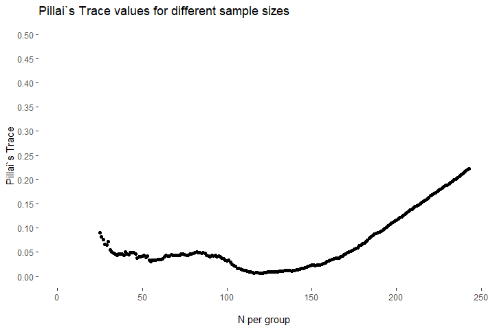

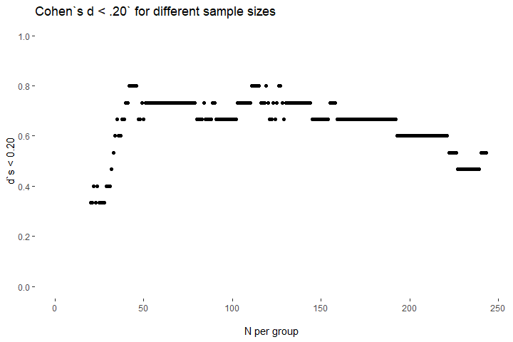

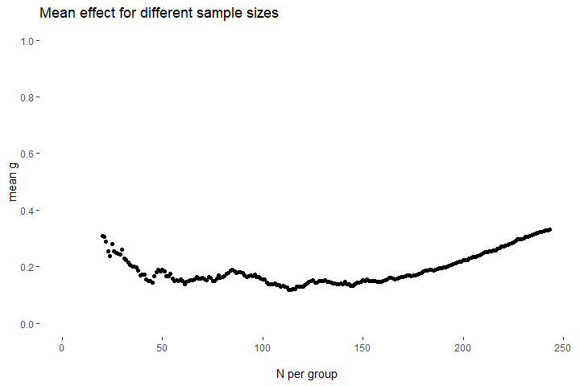

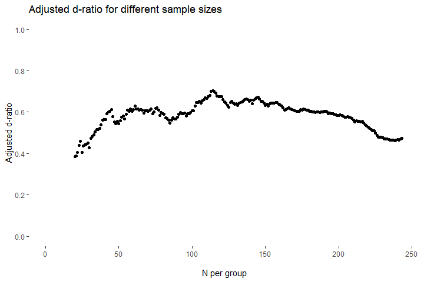

```r
# Plotting trend over increasing sample size
Plot_MAGMA(Balance = Balance_tar_exact,
           criterion = c("Pillai", "d_ratio", "mean_g", "Adj_d_ratio")) #Could be omitted
```

```r
# Creating table
Table_MAGMA(Balance = Balance_tar_exact,
            filename = "Balance_tar_exact.docx")
```

```
#> Balance table successfully created!
#> # A tibble: 4 × 6
#>   Criterion_optimized Pillai_Trace d_ratio mean_g adjusted_d_ratio n_per_group
#>   <chr>                      <dbl>   <dbl>  <dbl>            <dbl>       <int>
#> 1 Best mean g                 0.01    0.8    0.12             0.7          113
#> 2 Best adj. d-ratio           0.01    0.8    0.12             0.7          114
#> 3 Best Pillai                 0.01    0.73   0.12             0.69         116
#> 4 Best d-ratio                0.01    0.8    0.14             0.65         127
```

```r
# Computing descriptive statistics and pairwise effects for 100 cases per group
descs_tar_post_exact <- MAGMA_desc(Data = MAGMA_sim_data_tar_exact,
                                   group = "teacher_ability_rating",
                                   covariates = covariates_tar,
                                   step_num = 100,
                                   step_var = "step",
                                   filename = "stats_tar_post_exact.docx")

# Displaying the table with defined column names
descs_tar_post_exact %>%
    purrr::set_names(c("Overall N", "Overall Mean", "Overall SD",
                       "BA N", "BA Support Mean", "BA Support SD",
                       "A N", "A Mean", "A SD",
                       "AA N", "AA Mean", "AA SD",
                       "d BA-A", "d BA-AA", "d A-AA"))
```

```
#>                        Overall N Overall Mean Overall SD BA N BA Support Mean
#> teacher_ability_rating       300         2.00       0.82  100            1.00
#> GPA_school                   300         3.21       0.65  100            3.37
#> IQ_score                     300        98.95      13.11  100          101.40
#> Motivation                   300         3.83       0.91  100            3.82
#> parents_academic             300         0.38       0.49  100            0.42
#> gifted_support               300         0.39       0.49  100            0.42
#>                        BA Support SD A N A Mean  A SD AA N AA Mean AA SD d BA-A
#> teacher_ability_rating          0.00 100   2.00  0.00  100    3.00  0.00   -Inf
#> GPA_school                      0.68 100   3.13  0.64  100    3.13  0.60   0.37
#> IQ_score                       11.93 100  97.36 11.53  100   98.07 15.30   0.35
#> Motivation                      0.91 100   3.73  0.91  100    3.95  0.90   0.10
#> parents_academic                0.50 100   0.36  0.48  100    0.36  0.48   0.12
#> gifted_support                  0.50 100   0.36  0.48  100    0.40  0.49   0.12
#>                        d BA-AA d A-AA
#> teacher_ability_rating    -Inf   -Inf
#> GPA_school                0.38   0.00
#> IQ_score                  0.24  -0.05
#> Motivation               -0.14  -0.24
#> parents_academic          0.12   0.00
#> gifted_support            0.04  -0.08
```

# 2x2/four-group Example

In this 2x2-design example the variables `gifted_support` and `enrichment` are the independent (i.e., the treatment) variables. We are interested in how receiving giftedness support and the participation in afternoon enrichment affect the college GPA. The process of matching and balance evaluation is the same as in the previous examples. The grouping variable consists of two variables, so we use a character vector as input for the grouping variable (`c("gifted_support", "enrichment")`). Consequently, we also adapt the distance variable/propensity score (`ps_2x2`). Moreover, we use the same covariates as in the two-group example. Note that this 2x2 matching is largely equivalent to a 1x4 matching. Thus, using the multinominal variable `support_enrichment` as grouping variable would lead to similar results. In this example, we focus on the 2x2 case only.

Major distinctions between such a multinominal four-group matching and a 2x2 matching occur only in the balance estimation. Because of the changes in grouping variable and covariates, we need to estimate the initial unbalance for the two independent variables `gifted_support` and `enrichment`. The result of the `initial_unbalance` function changes slightly in this two-factorial design. Pillai’s Trace is estimated separately for the two main effects and the interaction. Thus, *d*-ratio, mean *g*, and adjusted *d*-ratio are the same for a 2x2 or a four-group matching, while changes occur only for Pillai’s Trace. In a first step, we define the covariates and estimate initial unbalance, descriptive statistics, and area of common support.

```r
# Defining the covariates
covariates_2x2 <- c("GPA_school",
                    "IQ_score",
                    "Motivation",
                    "parents_academic",
                    "gender")

# Computing descriptive statistics and all pairwise effects
descs_2x2_pre <- MAGMA_desc(Data = MAGMA_sim_data,
                            group = c("gifted_support", "enrichment"),
                            covariates = covariates_2x2,
                            filename = "stats_2x2_pre.docx")
```

```
#> 2x2 groups are represented as 4 groups.
```

```r
descs_2x2_pre %>%
  purrr::set_names(c("Overall N", "Overall Mean", "Overall SD",
                     "Sup & No En N", "Sup & No En Mean",
                     "Sup & No En SD",
                     "Sup & En N", "Sup & En Mean", "Sup & En SD",
                     "No Sup & No En N", "No Sup & No En Mean", "No Sup & No En SD",
                     "No Sup & En N", "No Sup & En Mean", "No Sup & En SD",
                     "d YesNo-YesYes", "d YesNo-NoNo", "d YesNo-NoYes",
                     "d YesYes-NoNo", "d YesYes-YNoYes",
                     "d NoNo-NoYes"))
```

```
#>                  Overall N Overall Mean Overall SD Sup & No En N
#> group_long             800         2.63       1.07           175
#> GPA_school             800         3.29       0.93           175
#> IQ_score               800       100.51      15.00           175
#> Motivation             800         3.82       0.89           175
#> parents_academic       800         0.40       0.49           175
#> gender                 800         0.50       0.50           175
#>                  Sup & No En Mean Sup & No En SD Sup & En N Sup & En Mean
#> group_long                   1.00           0.00        130          2.00
#> GPA_school                   3.44           0.88        130          3.71
#> IQ_score                   105.09          14.09        130        110.26
#> Motivation                   3.79           0.90        130          3.89
#> parents_academic             0.43           0.50        130          0.53
#> gender                       0.49           0.50        130          0.48
#>                  Sup & En SD No Sup & No En N No Sup & No En Mean
#> group_long              0.00              309                3.00
#> GPA_school              0.88              309                3.01
#> IQ_score               12.74              309               94.27
#> Motivation              0.86              309                3.75
#> parents_academic        0.50              309                0.37
#> gender                  0.50              309                0.50
#>                  No Sup & No En SD No Sup & En N No Sup & En Mean
#> group_long                    0.00           186             4.00
#> GPA_school                    0.93           186             3.31
#> IQ_score                     13.30           186            99.74
#> Motivation                    0.89           186             3.92
#> parents_academic              0.48           186             0.32
#> gender                        0.50           186             0.51
#>                  No Sup & En SD d YesNo-YesYes d YesNo-NoNo d YesNo-NoYes
#> group_long                 0.00           -Inf         -Inf          -Inf
#> GPA_school                 0.86          -0.31         0.47          0.15
#> IQ_score                  15.01          -0.38         0.80          0.37
#> Motivation                 0.90          -0.11         0.04         -0.14
#> parents_academic           0.47          -0.20         0.12          0.23
#> gender                     0.50           0.02        -0.02         -0.04
#>                  d YesYes-NoNo d YesYes-YNoYes d NoNo-NoYes
#> group_long                -Inf            -Inf         -Inf
#> GPA_school                0.77            0.46        -0.33
#> IQ_score                  1.22            0.75        -0.39
#> Motivation                0.16           -0.03        -0.19
#> parents_academic          0.33            0.44         0.11
#> gender                   -0.04           -0.06        -0.02
```

```r
# Estimating initial unbalance
unbalance_2x2 <- initial_unbalance(Data = MAGMA_sim_data,
                                   group = c("gifted_support", "enrichment"),
                                   covariates = covariates_2x2)
```

```
#> [1] "Mean g was computed using robust variance meta-analysis with robumeta."
```

```r
unbalance_2x2
```

```
#>           Pillai's Trace gifted_support Pillai's Trace enrichment
#> Unbalance                          0.13                      0.05
#>           Pillai's Trace IA d-ratio Mean g adj. d-ratio
#> Unbalance              0.01    0.53   0.29         0.53
```

```r
# Estimating and plotting density overlap in gifted support & enrichment propensity score
Density_overlap(Data = MAGMA_sim_data,
                variable = "ps_2x2",
                group = c("gifted_support", "enrichment"),
                variable_name = "Propensity Score",
                group_labels = c("No Support & No Enrichment",
                                 "No Support & Enrichment",
                                 "Support & No Enrichment",
                                 "Support & Enrichment"),
                group_name = "Gifted Support & Enrichment")
```

```
#> 2x2 groups are represented as 4 groups.
```

```r
# Defining the covariates
covariates_2x2 <- c("GPA_school",
                    "IQ_score",
                    "Motivation",
                    "parents_academic",
                    "gender")

# Computing descriptive statistics and all pairwise effects
descs_2x2_pre <- MAGMA_desc(Data = MAGMA_sim_data,
                            group = c("gifted_support", "enrichment"),
                            covariates = covariates_2x2,
                            filename = "stats_2x2_pre.docx")
```

```
#> 2x2 groups are represented as 4 groups.
```

```r
descs_2x2_pre %>%
  purrr::set_names(c("Overall N", "Overall Mean", "Overall SD",
                     "Sup & No En N", "Sup & No En Mean",
                     "Sup & No En SD",
                     "Sup & En N", "Sup & En Mean", "Sup & En SD",
                     "No Sup & No En N", "No Sup & No En Mean", "No Sup & No En SD",
                     "No Sup & En N", "No Sup & En Mean", "No Sup & En SD",
                     "d YesNo-YesYes", "d YesNo-NoNo", "d YesNo-NoYes",
                     "d YesYes-NoNo", "d YesYes-YNoYes",
                     "d NoNo-NoYes"))
```

```
#>                  Overall N Overall Mean Overall SD Sup & No En N
#> group_long             800         2.63       1.07           175
#> GPA_school             800         3.29       0.93           175
#> IQ_score               800       100.51      15.00           175
#> Motivation             800         3.82       0.89           175
#> parents_academic       800         0.40       0.49           175
#> gender                 800         0.50       0.50           175
#>                  Sup & No En Mean Sup & No En SD Sup & En N Sup & En Mean
#> group_long                   1.00           0.00        130          2.00
#> GPA_school                   3.44           0.88        130          3.71
#> IQ_score                   105.09          14.09        130        110.26
#> Motivation                   3.79           0.90        130          3.89
#> parents_academic             0.43           0.50        130          0.53
#> gender                       0.49           0.50        130          0.48
#>                  Sup & En SD No Sup & No En N No Sup & No En Mean
#> group_long              0.00              309                3.00
#> GPA_school              0.88              309                3.01
#> IQ_score               12.74              309               94.27
#> Motivation              0.86              309                3.75
#> parents_academic        0.50              309                0.37
#> gender                  0.50              309                0.50
#>                  No Sup & No En SD No Sup & En N No Sup & En Mean
#> group_long                    0.00           186             4.00
#> GPA_school                    0.93           186             3.31
#> IQ_score                     13.30           186            99.74
#> Motivation                    0.89           186             3.92
#> parents_academic              0.48           186             0.32
#> gender                        0.50           186             0.51
#>                  No Sup & En SD d YesNo-YesYes d YesNo-NoNo d YesNo-NoYes
#> group_long                 0.00           -Inf         -Inf          -Inf
#> GPA_school                 0.86          -0.31         0.47          0.15
#> IQ_score                  15.01          -0.38         0.80          0.37
#> Motivation                 0.90          -0.11         0.04         -0.14
#> parents_academic           0.47          -0.20         0.12          0.23
#> gender                     0.50           0.02        -0.02         -0.04
#>                  d YesYes-NoNo d YesYes-YNoYes d NoNo-NoYes
#> group_long                -Inf            -Inf         -Inf
#> GPA_school                0.77            0.46        -0.33
#> IQ_score                  1.22            0.75        -0.39
#> Motivation                0.16           -0.03        -0.19
#> parents_academic          0.33            0.44         0.11
#> gender                   -0.04           -0.06        -0.02
```

```r
# Estimating initial unbalance
unbalance_2x2 <- initial_unbalance(Data = MAGMA_sim_data,
                                   group = c("gifted_support", "enrichment"),
                                   covariates = covariates_2x2)
```

```
#> [1] "Mean g was computed using robust variance meta-analysis with robumeta."
```

```r
unbalance_2x2
```

```
#>           Pillai's Trace gifted_support Pillai's Trace enrichment
#> Unbalance                          0.13                      0.05
#>           Pillai's Trace IA d-ratio Mean g adj. d-ratio
#> Unbalance              0.01    0.53   0.29         0.53
```

```r
# Estimating and plotting density overlap in gifted support & enrichment propensity score
Density_overlap(Data = MAGMA_sim_data,
                variable = "ps_2x2",
                group = c("gifted_support", "enrichment"),
                variable_name = "Propensity Score",
                group_labels = c("No Support & No Enrichment",
                                 "No Support & Enrichment",
                                 "Support & No Enrichment",
                                 "Support & Enrichment"),
                group_name = "Gifted Support & Enrichment")
```

```
#> 2x2 groups are represented as 4 groups.
```

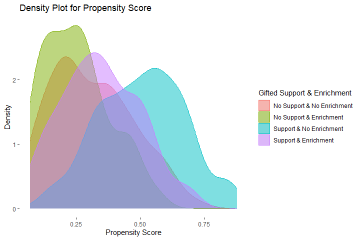

```
#>                                                         OV
#>                                                  0.8692442
#> OVPairs.No Support & No Enrichment-No Support & Enrichment
#>                                                  0.8264343
#> OVPairs.No Support & No Enrichment-Support & No Enrichment
#>                                                  0.6062432
#>    OVPairs.No Support & No Enrichment-Support & Enrichment
#>                                                  0.8951293
#>    OVPairs.No Support & Enrichment-Support & No Enrichment
#>                                                  0.4478171
#>       OVPairs.No Support & Enrichment-Support & Enrichment
#>                                                  0.7450427
#>       OVPairs.Support & No Enrichment-Support & Enrichment
#>                                                  0.6573491
```

## Standard Matching

```r
MAGMA_sim_data_2x2 <- MAGMA(Data = MAGMA_sim_data,
                            group = c("gifted_support", "enrichment"),
                            dist = "ps_2x2",
                            cores = 2)
```

```
#>
#>  Input correctly identified.
#>  Large number of groups with large group sizes. Computing quasi-systematic matching. Cores were reduced to 2 to simplify node communication despite high RAM usage.
#>  Matching complete!
```

```r
str(MAGMA_sim_data_2x2)
```

```
#> 'data.frame':    800 obs. of  18 variables:
#>  $ ID                    : int  1 2 3 4 5 6 7 8 9 10 ...
#>  $ gender                : int  1 0 1 1 1 0 0 0 1 0 ...
#>  $ gifted_support        : int  1 1 1 1 1 1 0 1 0 1 ...
#>  $ teacher_ability_rating: int  3 2 2 1 3 3 2 2 1 1 ...
#>  $ enrichment            : int  0 1 0 1 0 0 0 0 0 1 ...
#>  $ parents_academic      : int  1 1 1 0 1 0 0 1 0 0 ...
#>  $ GPA_school            : num  4.73 4.41 3.23 2.88 2.98 ...
#>  $ IQ_score              : num  111.6 97.8 120.1 97.9 74.4 ...
#>  $ Motivation            : num  5.36 4.41 3.57 4.34 3.54 ...
#>  $ college_GPA           : num  4.01 3.41 2.73 4.02 4.09 ...
#>  $ support_enrichment    : int  3 4 3 4 3 3 1 3 1 4 ...
#>  $ ps_tar                : num  0.0657 0.1085 0.1899 0.4261 0.4782 ...
#>  $ ps_2x2                : num  0.3 0.32 0.21 0.237 0.571 ...
#>  $ ps_gifted             : num  0.431 0.364 0.626 0.353 0.187 ...
#>  $ group_long            : num  1 2 1 2 1 1 3 1 3 2 ...
#>  $ step                  : num  71 41 35 19 NA 12 NA NA NA 105 ...
#>  $ weight                : num  1 1 1 1 NA 1 NA NA NA 1 ...
#>  $ distance              : num  3.61e-03 2.15e-04 1.24e-04 4.69e-05 NA ...
```

```r
MAGMA_sim_data_2x2 <- MAGMA(Data = MAGMA_sim_data,
                            group = c("gifted_support", "enrichment"),
                            dist = "ps_2x2",
                            cores = 2)
```

```r
str(MAGMA_sim_data_2x2)
```

```
#> 'data.frame':    800 obs. of  18 variables:
#>  $ ID                    : int  1 2 3 4 5 6 7 8 9 10 ...
#>  $ gender                : int  1 0 1 1 1 0 0 0 1 0 ...
#>  $ gifted_support        : int  1 1 1 1 1 1 0 1 0 1 ...
#>  $ teacher_ability_rating: int  3 2 2 1 3 3 2 2 1 1 ...
#>  $ enrichment            : int  0 1 0 1 0 0 0 0 0 1 ...
#>  $ parents_academic      : int  1 1 1 0 1 0 0 1 0 0 ...
#>  $ GPA_school            : num  4.73 4.41 3.23 2.88 2.98 ...
#>  $ IQ_score              : num  111.6 97.8 120.1 97.9 74.4 ...
#>  $ Motivation            : num  5.36 4.41 3.57 4.34 3.54 ...
#>  $ college_GPA           : num  4.01 3.41 2.73 4.02 4.09 ...
#>  $ support_enrichment    : int  3 4 3 4 3 3 1 3 1 4 ...
#>  $ ps_tar                : num  0.0657 0.1085 0.1899 0.4261 0.4782 ...
#>  $ ps_2x2                : num  0.3 0.32 0.21 0.237 0.571 ...
#>  $ ps_gifted             : num  0.431 0.364 0.626 0.353 0.187 ...
#>  $ group_long            : num  1 2 1 2 1 1 3 1 3 2 ...
#>  $ step                  : num  71 41 35 19 NA 12 NA NA NA 105 ...
#>  $ weight                : num  1 1 1 1 NA 1 NA NA NA 1 ...
#>  $ distance              : num  3.61e-03 2.15e-04 1.24e-04 4.69e-05 NA ...
```